# Étude Économétrique - Croissance économique

Pierre Dumont-Roty, Rachel Mellot, Chloé Martin

2025-01-07

# Présentation de la question de recherche

La croissance économique est un indicateur central pour évaluer la performance des économies. Comprendre les déterminants de la croissance du PIB est un enjeu pour les économistes, les investisseurs mais également les décideurs politiques. La croissance économique, bien qu’importante, demeure complexe à expliquer en raison de l’interconnexion d’une multitude de facteurs macroéconomiques, structurels et sociaux.

Dans le cadre de cette étude, nous avons mobilisé des données de la base **World Developement Indicators (WDI)**. Nous avons fait le choix de nous concentrer sur 19 pays répartis entre l’Europe, l’Amérique, l’Asie, l’Afrique et l’Océanie : la France, l’Allemagne, l’Italie, la Norvège, le Royaume-Uni, la Grèce, l’Espagne, la Suisse, la Belgique, les États-Unis, le Brésil, le Mexique, la Chine, l’Inde, le Japon, l’Afrique du Sud, le Kenya, l’Australie et la Nouvelle-Zélande. Ce choix de pays repose sur leur diversité géographique, économique et sociale, offrant un cadre global pour analyser les dynamiques de croissance dans des contextes variés.

Notre sélection des variables explicatives repose sur des facteurs clés couramment identifiés dans la littérature économique, tels que : le pourcentage d’exportations, l’espérance de vie, le taux d’inflation, le taux de chômage. Ces variables permettent de capturer des dimensions économiques et sociales fondamentales susceptibles d’influencer la croissance.

A travers une analyse descriptive et économétrique, nous visons à identifier et quantifier l’influence des facteurs retenus sur la performance économique des pays étudiés, tout en tenant compte des particularités propres à chaque région du monde.

# Présentation des données

Ces variables explicatives sont les suivantes :

- **Les exportations (en % du PIB)** : une mesure de l’ouverture commerciale des pays et de leur compétitivité sur les marchés internationaux.
- **L’investissement (formation brute de capital fixe)** : un indicateur essentiel pour évaluer le rôle des dépenses en infrastructures, en équipements et en technologies dans la croissance économique.
- **L’espérance de vie à la naissance (en années)** : une mesure indirecte du développement humain et de la qualité du système de santé, qui peut refléter l’impact des conditions sociales sur la productivité.
- **Le taux d’inflation (% annuel)** : un facteur macroéconomique clé influençant la stabilité des prix, le pouvoir d’achat et les décisions d’investissement.
- **Le taux de chômage (% de la population active)** : un indicateur du niveau d’emploi et du dynamisme du marché du travail.

Pour garantir la pertinence et la cohérence de notre analyse, nous avons choisi de nous concentrer sur une période récente de cinq ans, allant de 2018 à 2022. Cette période nous permet de capturer des dynamiques économiques contemporaines tout en évitant des biais liés à des données trop anciennes ou instables.

Enfin, pour donner un aperçu concret de notre base de données, nous présentons ci-dessous un extrait des données de panel mobilisées dans cette étude.

| country | year | growth_gdp | exports | investment | life_expectancy | inflation | unemployment |
| --- | --- | --- | --- | --- | --- | --- | --- |
| Australia | 2018 | 2.8784697 | 21.89409 | 24.64641 | 82.74878 | 1.9114009 | 5.300 |
| Australia | 2019 | 2.1715451 | 24.15968 | 23.39129 | 82.90000 | 1.6107679 | 5.159 |
| Australia | 2020 | -0.1195907 | 24.02674 | 22.42773 | 83.20000 | 0.8469055 | 6.456 |
| Australia | 2021 | 2.1111681 | 22.05668 | 22.93724 | 83.30000 | 2.8639104 | 5.116 |
| Australia | 2022 | 4.2423856 | 25.53159 | 23.76819 | 83.20000 | 6.5940967 | 3.701 |
| Belgium | 2018 | 1.8779686 | 83.48306 | 25.55158 | 81.59512 | 2.0531650 | 5.948 |
| Belgium | 2019 | 2.4428901 | 82.96743 | 24.67568 | 81.99512 | 1.4368196 | 5.360 |
| Belgium | 2020 | -4.7929839 | 79.19687 | 24.06857 | 80.69512 | 0.7407918 | 5.555 |
| Belgium | 2021 | 6.2025540 | 89.62961 | 24.44248 | 81.79024 | 2.4402485 | 6.264 |
| Belgium | 2022 | 4.2334318 | 95.26780 | 26.93674 | 81.69756 | 9.5975117 | 5.558 |

* Source : Base WDI, analyse économétrique

# Analyse descriptive des données

Afin de mieux appréhender les caractéristiques de notre échantillon et d’explorer les relations potentielles entre les variables étudiées, nous avons réalisé une analyse descriptive des données. Cette étape est essentielle pour avoir une vue d’ensemble sur la distribution et les tendances des variables, tout en identifiant d’éventuelles anomalies ou variations significatives.

Nous présentons ci-dessous un résumé des principales statistiques descriptives des variables retenues pour l’étude : la croissance du PIB, les exportations, l’investissement, l’espérance de vie, l’inflation et le taux de chômage. Ces statistiques couvrent un échantillon de 19 pays sur la période récente de 2018 à 2022.

Les indicateurs clés comme la moyenne, l’écart-type, les valeurs minimales et maximales permettent de mieux comprendre les caractéristiques structurelles des variables et les variations observées entre les pays ou au cours de la période.

Résumé des statistiques descriptives des variables (2018-2022)

| Indicators | Mean | Sd | Min | Max |
| --- | --- | --- | --- | --- |
| growth_gdp | 1.927896 | 4.271225 | -10.940071 | 9.689592 |
| exports | 32.815718 | 18.659712 | 9.641869 | 95.267802 |
| investment | 23.242411 | 6.479840 | 12.099660 | 43.793475 |
| life_expectancy | 78.306119 | 6.590840 | 61.427000 | 84.560000 |
| inflation | 3.210631 | 2.644982 | -1.247984 | 9.645260 |
| unemployment | 7.644432 | 5.864807 | 2.351000 | 28.838000 |

L’analyse des statistiques descriptives révèle des caractéristiques intéressantes de notre échantillon. Parmi les variables étudiées, l’espérance de vie se distingue par une certaine variabilité entre les pays, bien qu’elle reste relativement élevée dans l’ensemble. Tandis que des pays développés tels que la France, l’Allemagne, les États-Unis ou le Japon affichent des espérances de vie proches les unes des autres. Certains pays comme le Brésil ou l’Afrique du Sud présentent des niveaux plus faibles, ce qui témoigne d’écarts notables dans les systèmes de santé et les conditions de vie, malgré une dynamique de croissance économique parfois comparable. Cette hétérogénéité dans l’espérance de vie reflète la diversité des niveaux de développement humain dans notre échantillon.

En revanche, une hétérogénéité marquée apparaît pour les autres variables :

- **Les exportations** (% du PIB) et **l’investissement** montrent des écarts significatifs, traduisant des structures économiques différentes. Certaines économies, comme celles des États-Unis ou de la Chine, sont davantage orientées vers le commerce international ou l’accumulation de capital, tandis que d’autres, comme l’Inde ou l’Afrique du Sud, peuvent être moins intégrées à l’économie mondiale.
- **Le taux d’inflation** et **le taux de chômage** varient également de manière marquée, ce qui reflète des politiques macroéconomiques distinctes ainsi que des spécificités nationales dans la gestion du marché du travail ou de la stabilité des prix. Par exemple, les taux d’inflation sont relativement bas dans les économies développées, mais peuvent être plus élevés dans des pays comme le Brésil ou le Mexique, qui font face à des défis économiques particuliers.
- Enfin, **la croissance du PIB** présente des variations notables, signe que ces pays, bien qu’économiquement comparables dans certains cas, suivent des trajectoires de croissance distinctes sur la période étudiée (2018-2022). Cela est particulièrement visible entre les économies émergentes comme la Chine et l’Inde, d’une part, et les pays plus développés, d’autre part.

Ces premières observations soulignent à la fois des similitudes structurantes entre les pays développés (comme l’espérance de vie élevée et stable) et des différences significatives dans les dynamiques économiques, en particulier entre les économies développées et émergentes, qui seront explorées davantage dans les sections suivantes.

## Représentation des variables

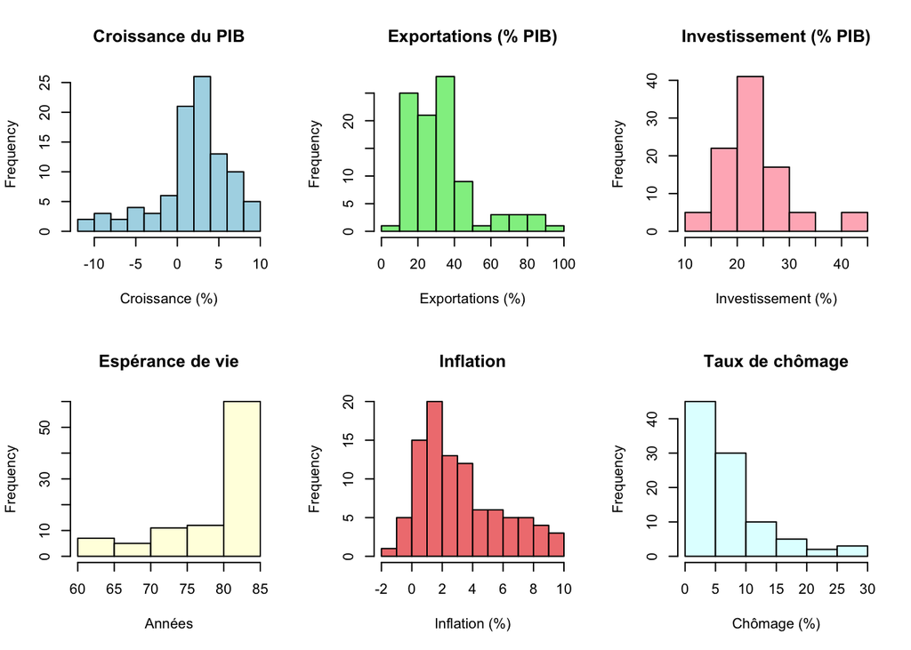

## Evolution de la croissance du PIB

Afin d’observer l’évolution temporelle de la croissance du PIB pour chaque pays de notre échantillon, nous avons tracé la série chronologique de cette variable sur la période 2018-2022. Le graphique ci-dessous présente la croissance du PIB (%) par pays, ce qui permet de visualiser les tendances économiques pour chaque nation.

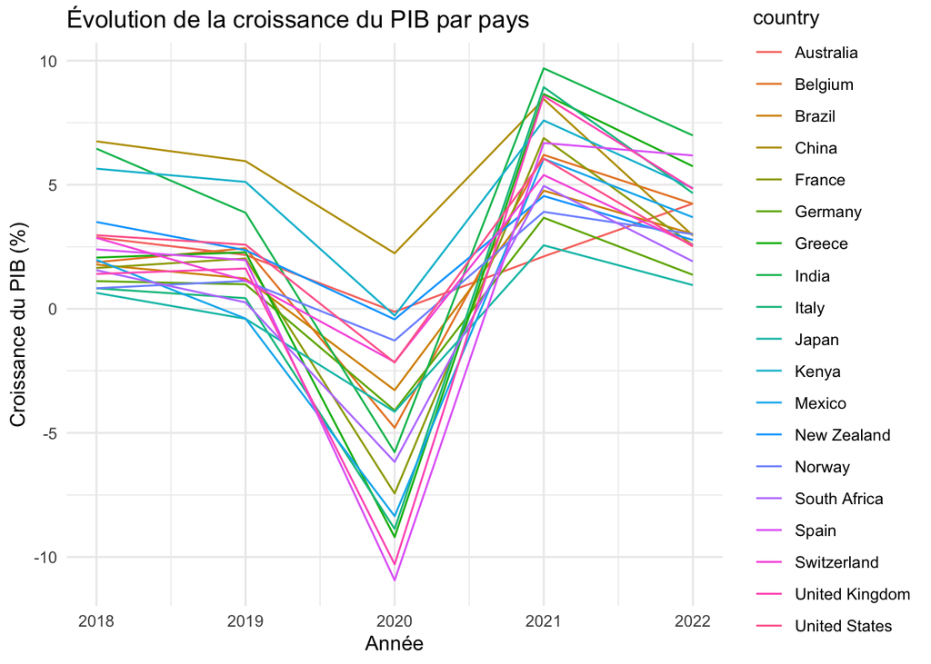

Le graphique nous permet de tirer plusieurs conclusions importantes concernant la dynamique économique des pays étudiés.

Nous observons que, bien que les pays de notre échantillon suivent une tendance similaire au fil du temps, avec des disparités marquées apparaissent entre eux, particulièrement après la crise de 2020.

Plus précisément, une chute importante de la croissance du PIB est visible en 2020, année marquée par les effets dévastateurs de la pandémie de COVID-19. Toutefois, cette baisse n’a pas été homogène. La Chine, en tête, a montré une reprise rapide après le choc initial, tandis que des pays comme le Royaume-Uni ou l’Espagne ont connu des baisses de croissance supérieures à 10%, ce qui reflète probablement l’impact majeur de la crise sanitaire sur leurs économies respectives. Ces pays ont été confrontés à de sévères confinements, à la réduction des activités économiques et à des perturbations dans le commerce international.

En revanche, certains pays, comme le Japon, l’Australie, la Norvège ou la Suisse, ont connu une évolution plus favorable, avec une chute de la croissance moins prononcée, voire une reprise plus rapide. Cela pourrait être attribué à des facteurs spécifiques, tels qu’une meilleure gestion de la crise sanitaire, des secteurs économiques moins vulnérables à la pandémie, ou encore des mécanismes de soutien gouvernementaux plus efficaces.

Hormis la crise de 2020, des divergences persistantes sont visibles : des pays comme la Chine ou l’Inde affichent des taux de croissance du PIB bien plus élevés que des économies européennes ou d’Amérique du Sud. Par ailleurs, les États-Unis et le Japon suivent des trajectoires relativement stables. A l’inverse, des pays comme le Royaume-Uni ou l’Espagne connaissent encore des fluctuations importantes. Ces observations suggèrent que la résilience économique face à des crises mondiales peut varier en fonction des politiques économiques, des structures industrielles et des réponses sanitaires nationales.

Ce premier aperçu nous incite à aller plus loin dans l’analyse pour comprendre quelles variables spécifiques peuvent expliquer ces variations dans la croissance du PIB. À partir de ce point, nous pourrions développer des modèles économétriques pour tester l’influence de facteurs tels que l’investissement, l’inflation ou le taux de chômage sur ces fluctuations.

## Analyse des relations entre les variables explicatives : Matrice de corrélation

Pour mieux comprendre les interactions et les relations linéaires entre nos variables explicatives, nous avons calculé une matrice de corrélation et généré un graphique de corrélation associé. Ce dernier nous permet de visualiser rapidement les liens entre les différentes variables économiques et de mettre en évidence les relations qui pourraient influencer la croissance du PIB.

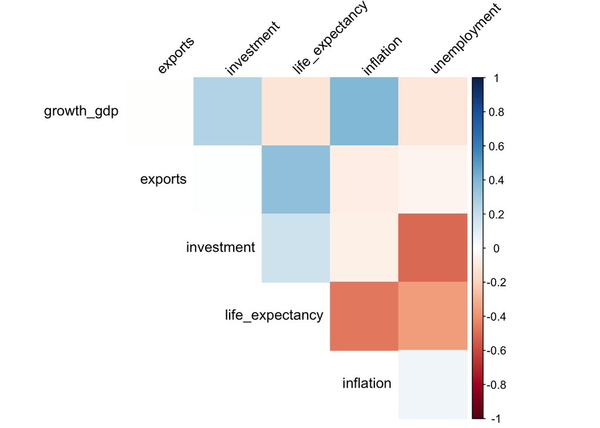

L’analyse de la matrice de corrélation nous permet de dégager plusieurs observations clées concernant les relations entre les variables :

Nous observons une corrélation négative entre l’investissement et le taux de chômage, ce qui est cohérent avec les attentes économiques théoriques. En effet, un niveau plus élevé d’investissement (notamment dans des projets d’infrastructure ou de nouvelles technologies) tend à créer des emplois, ce qui réduit le taux de chômage. Cette relation suggère qu’une politique d’investissement public ou privé peut avoir un impact positif sur l’emploi.

Une corrélation négative entre l’espérance de vie et l’inflation est également observée. Cela suggère qu’une plus haute espérance de vie est associée à un taux d’inflation plus faible. Cela pourrait indiquer que les pays avec une population vivant plus longtemps bénéficient d’une plus grande stabilité économique, ou encore que des économies plus développées et stables (ayant tendance à offrir une meilleure qualité de vie) ont des taux d’inflation plus maîtrisés.

Par ailleurs, une corrélation positive modérée entre l’inflation et la croissance du PIB est également visible. Cela pourrait refléter une relation classique dans les modèles économiques, où une inflation modérée est souvent associée à une économie en croissance, résultant d’une demande accrue et de la stimulation des activités économiques. Toutefois, cette relation peut également indiquer des pressions inflationnistes dues à une demande excédentaire dans certaines économies.

Cependant, bien que la matrice révèle des liens intéressants, il est important de noter que la corrélation ne prouve pas de causalité. Pour tester des relations causales et approfondir notre compréhension des mécanismes sous-jacents, il serait pertinent de mener des analyses économétriques plus avancées, telles que des modèles de régression, afin d’isoler les effets de chaque variable sur la croissance du PIB.

# Présentation des différentes spécifications possibles

Pour analyser la relation entre la croissance économique (croissance du PIB) et les variables explicatives telles que les exportations, l’investissement, l’espérance de vie, l’inflation et le taux de chômage, nous avons spécifié plusieurs modèles économétriques. Nous avons spécifié un modèle poolé, un modèle à effets fixes (within) et un modèle à effets aléatoires. Nous précisons que, pour tous ces modèles, les erreurs types ont été corrigées.

Les modèles sont basés sur des données de panel couvrant plusieurs pays dans le monde entier sur la période de 2018 à 2022. Les variables explicatives sont mesurées en termes absolus, mais afin de mieux capturer les relations relatives entre les variables, nous avons transformé certaines de ces variables en logarithmes. Cette transformation est particulièrement pertinente pour les variables économiques ayant une forte hétérogénéité dans leur échelle de mesure, comme les exportations et l’investissement.

$$ln(GDP growth_{it})
=\beta_0+\beta_{1}ln(Exports_{it})+\beta_{2}ln(investment_{it})+\beta_{3}life_expectancy_{it}
\\ +\beta_{4}ln(inflation_{it})+\beta_{5}ln(unemployment_{it})
+\epsilon_{it} , \forall i \in [1,19],\forall t \in [1,5]$$
L’utilisation du logarithme sur certaines variables permet de linéariser les relations, travailler avec des taux de croissance relatifs, et réduire l’asymétrie des données. En résumé, l’utilisation du logarithme permet de rendre les résultats plus interprétables et de mieux capturer les effets économiques sous-jacents.

## Modèle poolé

Le modèle poolé suppose que toutes les observations sont combinées en une seule base de données, sans distinction entre les individus (pays dans notre cas). Autrement dit, tous les pays sont supposés être identiques, sans effets individuels spécifiques.

Ce modèle est utilisé lorsque l’on considère que les relations entre les variables explicatives et la variable dépendante sont homogènes à travers les différents pays. Le modèle poolé n’inclut pas d’effets spécifiques à chaque pays, et suppose donc que toutes les observations proviennent de la même distribution.

**Modèle Poolé**

|  | *Dependent variable:* |
| --- | --- |
|  | log(growth_gdp) |
| log(exports) | 0.012 |
|  | (0.135) |
| log(investment) | 0.937*** |
|  | (0.295) |
| life_expectancy | -0.013 |
|  | (0.019) |
| log(inflation) | 0.248** |
|  | (0.097) |
| log(unemployment) | 0.172 |
|  | (0.225) |
| Constant | -1.422 |
|  | (1.801) |
| Observations | 74 |
| R<sup>2</sup> | 0.186 |
| Adjusted R<sup>2</sup> | 0.127 |
| F Statistic | 3.118** (df = 5; 68) |
| *Note:* | p<0.1; p<0.05; p<0.01 |

Après estimation de ce modèle, nous avons trouvé les résultats suivants :

- **Tous les coefficients sont positifs**, indiquant que les variables explicatives ont, en moyenne, un effet positif sur la croissance du PIB. Cependant, une exception notable concerne l’espérance de vie. En effet, pour chaque année supplémentaire d’espérance de vie, on observe une baisse de 1,3% du taux de croissance du PIB.
- **Le coefficient de l’investissement est hautement significatif** (p-value < 0.01), ce qui témoigne d’un effet positif et substantiel sur la croissance du PIB. En effet, une augmentation de 1% des investissements entraîne une hausse de 0.937 point de pourcentage dans la croissance du PIB. Cela met en évidence l’importance de l’investissement en tant que moteur de la croissance économique, ce qui est conforme à la théorie économique qui postule que l’accumulation de capital stimule l’activité économique.
- Le coefficient de **l’inflation est modérément significatif** (p-value < 0.05), suggérant que l’inflation exerce un effet positif sur la croissance du PIB. Bien que cet effet soit moins marqué que celui de l’investissement, il reste pertinent. Cela pourrait refléter une relation où une inflation modérée stimule la demande et l’activité économique, en particulier si elle est perçue comme un signe de dynamisme économique.
- Enfin, le coefficient de la variable “exports” n’est pas statistiquement significatif (p-value > 0.1), ce qui suggère que, dans le cadre de ce modèle, les exportations n’ont pas d’impact significatif sur la croissance du PIB.

Ces résultats montrent plusieurs coefficients peu significatifs, ce qui pourrait indiquer que la spécification du modèle poolé ne capture pas adéquatement les effets spécifiques à chaque pays et ne reflète pas bien la réalité des données. L’absence de différenciation entre les pays pourrait masquer des relations économiques sous-jacentes, suggérant qu’un modèle prenant en compte des effets fixes ou aléatoires pourrait mieux rendre compte des particularités économiques de chaque nation. Cette limite méthodologique appelle à une exploration plus approfondie avec des modèles plus sophistiqués qui tiennent compte de l’hétérogénéité entre les pays.

## Modèle within

Le modèle within (modèle à effets fixes) suppose que chaque pays possède un effet spécifique, constant au fil du temps. L’objectif de ce modèle est de contrôler les différences non observées entre les pays qui ne changent pas au cours du temps. Cela permet de se concentrer sur l’effet des variables explicatives au sein de chaque pays.

**Modèle Within**

|  | *Dependent variable:* |
| --- | --- |
|  | log(growth_gdp) |
| log(exports) | 0.671 |
|  | (0.899) |
| log(investment) | 0.479 |
|  | (1.116) |
| life_expectancy | -0.246*** |
|  | (0.073) |
| log(inflation) | 0.306** |
|  | (0.120) |
| log(unemployment) | 0.837 |
|  | (0.695) |
| Observations | 74 |
| R<sup>2</sup> | 0.359 |
| Adjusted R<sup>2</sup> | 0.064 |
| F Statistic | 5.606*** (df = 5; 50) |
| *Note:* | p<0.1; p<0.05; p<0.01 |

Dans cette estimation, plusieurs résultats importants émergent, notamment concernant les coefficients des variables :

- **Le coefficient associé à l’espérance de vie** devient désormais significatif et beaucoup plus fort que dans le modèle poolé mais il reste cependant toujours le seul coefficient à jouer négativement sur le taux de croissance du PIB.
- Le taux d’inflation reste une variable significative dans le modèle. Une augmentation de 1 % du taux d’inflation conduit à une augmentation de 0.306 % du taux de croissance du PIB, en moyenne. Ce résultat peut suggérer qu’une inflation modérée est souvent liée à une expansion économique, selon la théorie économique classique où une certaine inflation stimule la demande globale.
- Une augmentation de 1 % du taux de chômage fait augmenter le taux de croissance du PIB de 0.837 %, toutes choses égales par ailleurs. Ce résultat semble contre-intuitif, car on s’attend généralement à ce qu’une hausse du chômage soit négativement corrélée avec la croissance économique.

Les estimations obtenues dans le modèle à effets fixes semblent plus robustes et pertinentes par rapport à celles du modèle poolé, surtout en tenant compte du contexte spécifique des pays étudiés. En effet, il est bien connu qu’il existe des différences substantielles entre les pays, notamment au niveau de la structure économique, des politiques publiques et des facteurs sociaux. Le modèle à effets fixes permet de mieux capturer ces particularités nationales, ce qui le rend plus adapté à l’analyse des données de panel dans ce cas particulier.

## Modèle aléatoire

Le modèle à effets aléatoires suppose que les effets individuels (spécifiques à chaque pays) sont aléatoires et indépendants de la variable explicative. Ce modèle est particulièrement utile lorsque l’on suppose que les effets spécifiques à chaque pays peuvent varier de manière aléatoire et ne sont pas systématiques.

**Random Effect Model**

|  | *Dependent variable:* |
| --- | --- |
|  | log(growth_gdp) |
| log(exports) | 0.143 |
|  | (0.142) |
| log(investment) | 0.976*** |
|  | (0.364) |
| life_expectancy | -0.024 |
|  | (0.017) |
| log(inflation) | 0.290*** |
|  | (0.088) |
| log(unemployment) | 0.218 |
|  | (0.253) |
| Constant | -1.315 |
|  | (1.633) |
| Observations | 74 |
| R<sup>2</sup> | 0.186 |
| Adjusted R<sup>2</sup> | 0.126 |
| F Statistic | 16.904*** |
| *Note:* | p<0.1; p<0.05; p<0.01 |

Les résultats du modèle à effets aléatoires fournissent des informations intéressantes :

Les coefficients du modèle à effets aléatoires sont très proches de ceux du modèle poolé, tant en termes de magnitudes que de significativité. Cela suggère que, bien que nous ayons modélisé les effets aléatoires pour tenir compte des différences spécifiques entre les pays, les résultats obtenus sont relativement similaires à ceux du modèle poolé. Cela peut indiquer que les différences non observées entre les pays ne jouent pas un rôle majeur dans l’explication de la croissance du PIB pour cet échantillon particulier.

## Comparaison des trois modèles

Afin de choisir le modèle le plus approprié pour notre étude, nous allons comparer les trois spécifications mentionnées ci-dessus. Les résultats sont présentés dans le tableau suivant. Ce tableau montre les coefficients estimés pour chaque variable explicative dans les trois modèles.

**Comparaison des 3 modèles économétriques**

|  | *Dependent variable:* |  |  |
| --- | --- | --- | --- |
|  | log(growth_gdp) |  |  |
|  | Pooling | Fixed Effect | Random |
|  | (1) | (2) | (3) |
| log(exports) | 0.012 | 0.671 | 0.143 |
|  | (0.135) | (0.899) | (0.142) |
| log(investment) | 0.937*** | 0.479 | 0.976*** |
|  | (0.295) | (1.116) | (0.364) |
| life_expectancy | -0.013 | -0.246*** | -0.024 |
|  | (0.019) | (0.073) | (0.017) |
| log(inflation) | 0.248** | 0.306** | 0.290*** |
|  | (0.097) | (0.120) | (0.088) |
| log(unemployment) | 0.172 | 0.837 | 0.218 |
|  | (0.225) | (0.695) | (0.253) |
| Constant | -1.422 |  | -1.315 |
|  | (1.801) |  | (1.633) |
| Observations | 74 | 74 | 74 |
| R<sup>2</sup> | 0.186 | 0.359 | 0.186 |
| Adjusted R<sup>2</sup> | 0.127 | 0.064 | 0.126 |
| F Statistic | 3.118** (df = 5; 68) | 5.606*** (df = 5; 50) | 16.904*** |
| *Note:* | p<0.1; p<0.05; p<0.01 |  |  |

En comparant les trois modèles, nous observons que le modèle à effets fixes (within) se distingue par un R² plus élevé (0,359 contre 0,186 pour les modèles à effets aléatoires et poolé). Cela suggère que le modèle à effets fixes offre une meilleure qualité d’ajustement et explique une plus grande part de la variation de la variable dépendante (la croissance du PIB) par rapport aux modèles à effets aléatoires et poolé.

Bien que le R² soit un indicateur utile, il ne doit pas être le seul critère de choix du modèle. Néanmoins, cette première différence en termes de R² montre que le modèle à effets fixes pourrait mieux capturer les effets spécifiques propres à chaque pays, offrant ainsi une explication plus précise des dynamiques de croissance observées.

# Choix du modèle le plus approprié

Afin de choisir le modèle le plus adapté, nous avons utilisé des tests statistiques tels que le test de Hausman. L’hypothèse nulle du test de Hausman suppose que les effets individuels non-observés sont non corrélés aux explicatives et par conséquent, que le modèle à effets aléatoire serait plus pertient. En reavanche, si l’on rejette l’hypothèse nulle alors le modèle à effets fixes est approprié car on suppose une corrélation entre les effets spécifiques des pays et les variables explicatives.

Voici les résultats du test de Hausman :

**Hausman Test Results**

|  | Statistic | DF | P_Value |
| --- | --- | --- | --- |
| chisq | 9.022 | 5 | 0.108 |

Il convient tout d’abord de souligner que le test d’Hausman dans R n’est pas parfait et doit donc être interprété avec prudence.

Toutefois, sur la base de nos connaissances du sujet, il est difficile de démontrer que les effets individuels dans notre contexte ne sont pas corrélés avec les variables explicatives. En conséquence, bien que le test d’Hausman suggère l’usage d’un modèle à effets aléatoires, nous préférons retenir le modèle à effets fixes (within), qui semble mieux adapté à la structure des données et à notre compréhension du contexte.

Étant donné la diversité des pays dans notre échantillon, qui inclut des économies à des stades de développement différents, il est probable que des effets spécifiques à chaque pays jouent un rôle important dans la détermination de la croissance du PIB. Le modèle à effets fixes (within) permet de capturer ces différences structurelles et d’isoler l’impact des variables explicatives sur la croissance, sans interférence des particularités nationales non observées.

De plus, bien que le modèle à effets aléatoires soit adapté à certaines situations où les effets individuels sont supposés être non corrélés avec les variables explicatives, il peut entraîner des biais de spécification lorsque cette hypothèse est violée. Le modèle à effets fixes, en revanche, offre des estimations plus robustes et permet de prendre en compte les effets spécifiques à chaque pays. Cela améliore la précision de nos résultats, particulièrement dans un cadre où les politiques économiques et les structures économiques peuvent varier considérablement d’un pays à l’autre.

## Conclusion

L’objectif de cette étude étant de mieux comprendre les déterminants de la croissance économique dans différents pays, il était primordial d’adopter un modèle qui prend en compte les différences économiques, sociales et politiques spécifiques à chaque pays. Le modèle à effets fixes, en considérant ces différences comme des facteurs individuels non observés, est donc particulièrement pertinent dans ce contexte.